# Results to Date

Ebba Mark

2022-08-24

```r
# Summary tables
# Variables labels are NOT assigned -- need to modify dictionaries above
# when adding or removing variables from summary tables
allcompdf <- as.data.frame(allcomp)
allcompccdf <- as.data.frame(allcomp_cc)

stargazer(allcompdf[c("active_mines" ,"uer","employed", "unemployed",
                      "labour_force", "pop", "REE_inv",
                      "realgdp","realgdp_pc", "ruc", "ruc_bin",
                      "REE_inv_scaled_realgdp")], title = "Summary Statistics: Contiguous US Counties",
                      covariate.labels = sum_dict)
```

```
% Table created by stargazer v.5.2.3 by Marek Hlavac, Social Policy Institute. E-mail: marek.hlavac at gmail.com
% Date and time: Wed, Aug 24, 2022 - 06:11:27
\begin{table}[!htbp] \centering
  \caption{Summary Statistics: Contiguous US Counties}
  \label{}
\begin{tabular}{@{\extracolsep{5pt}}lccccc}
\\[-1.8ex]\hline
\hline \\[-1.8ex]
Statistic & \multicolumn{1}{c}{N} & \multicolumn{1}{c}{Mean} & \multicolumn{1}{c}{St. Dev.} & \multicolumn{1}{c}{Min} & \multicolumn{1}{c}{Max} \\
\hline \\[-1.8ex]
Active Mines (no.) & 55,296 & 0.462 & 3.723 & 0 & 114 \\
Unemployment Rate & 55,296 & 6.130 & 2.720 & 0.800 & 29.400 \\
Employed Persons & 55,296 & 46,504.600 & 149,661.300 & 34 & 4,888,581 \\
Unemployed Persons & 55,296 & 2,993.569 & 11,183.150 & 3 & 621,950 \\
Labour Force & 55,296 & 49,498.160 & 159,938.100 & 38 & 5,122,843 \\
Population & 55,296 & 99,440.810 & 318,828.000 & 55 & 10,105,708 \\
Total USDA RE Investments in USD & 55,296 & 114,142.500 & 2,670,894.000 & 0.000 & 250,000,000.000 \\
Coal Production (in short tons) & 55,296 & 5,140,646.000 & 22,046,739.000 & 7,648 & 726,943,301 \\
Real GDP & 55,296 & 50.845 & 463.903 & 5.787 & 59,848.920 \\
Real GDP Per Capita & 55,296 & 5.090 & 2.685 & 1 & 9 \\
Rural-Urban Code & 55,296 & 0.648 & 0.477 & 0 & 1 \\
Rural-Urban (binary) & 55,296 & 0.091 & 3.073 & 0.000 & 503.927 \\
\hline \\[-1.8ex]
\end{tabular}
\end{table}
```

```r
stargazer(allcompccdf[c("active_mines" ,"uer","employed", "unemployed",
                        "labour_force", "pop", "REE_inv",
                        "realgdp","realgdp_pc", "ruc", "ruc_bin",
                        "REE_inv_scaled_realgdp")], title = "Summary Statistics: US Coal Counties",
                        covariate.labels = sum_dict, type = "text")
```

```
Summary Statistics: US Coal Counties
========================================================================================
Statistic                          N       Mean        St. Dev.     Min        Max
----------------------------------------------------------------------------------------
Active Mines (no.)               4,518     5.653        11.847       0         114
Unemployment Rate                4,518     6.946         2.520     1.900      20.600
Employed Persons                 4,518  29,069.860    58,838.490    816      622,714
Unemployed Persons               4,518   1,933.251     3,535.003     32       46,564
Labour Force                     4,518  31,003.110    62,186.670    870      651,926
Population                       4,518  64,866.890    119,765.600  1,836    1,265,577
Total USDA RE Investments in USD 4,518  27,055.950    333,439.800  0.000  10,005,017.000
Coal Production (in short tons)  4,518 3,045,039.000 7,913,160.000 47,597   92,984,370
Real GDP                         4,518    41.688        25.763     8.221     244.161
Real GDP Per Capita              4,518     5.116         2.376       1          9
Rural-Urban Code                 4,518     0.697         0.460       0          1
Rural-Urban (binary)             4,518     0.016         0.241     0.000      8.964
----------------------------------------------------------------------------------------
```

```r
stargazer(allcompdf[c("diff_uer", "mines_diff","diff_log_realgdp",
                      "diff_log_realgdp_pc", "diff_log_employed",
                      "diff_log_unemployed", "diff_log_lf", "diff_log_pop",
                      "REE_bin_top90") ],
                      title = "Summary Statistics of Transformed Variables: Contiguous US Counties",
                      covariate.labels = sum_dict_trans, type = "text")
```

```
Summary Statistics of Transformed Variables: Contiguous US Counties
================================================================
Statistic                     N     Mean  St. Dev.  Min    Max
----------------------------------------------------------------
Δ Unemployment Rate         55,296 -0.061  1.228   -8.600 13.500
Δ Active Mines              55,296 -0.015  0.605    -30     20
Δ (log) Real GDP            55,295 0.017   0.088   -1.122 1.386
Δ (log) Real GDP per capita 55,295 0.014   0.088   -1.126 1.391
Δ (log) Employed Persons    55,296 0.001   0.037   -0.596 1.022
Δ (log) Unemployed Persons  55,296 -0.013  0.177   -0.852 1.305
Δ (log) Labour Force        55,296 0.001   0.034   -0.562 0.986
Δ (log) Population          55,295 0.003   0.014   -0.425 0.290
REE ≥ .1% of GDP            55,296 0.127   0.333     0      1
----------------------------------------------------------------
```

```r
stargazer(allcompccdf[c("diff_uer", "mines_diff","diff_log_realgdp",
                        "diff_log_realgdp_pc", "diff_log_employed",
                        "diff_log_unemployed", "diff_log_lf", "diff_log_pop",
                        "REE_bin_top90") ],
                        title = "Summary Statistics of Transformed Variables: US Coal Counties Subset",
                        covariate.labels = sum_dict_trans, type = "text")
```

```
Summary Statistics of Transformed Variables: US Coal Counties Subset
===============================================================
Statistic                     N    Mean   St. Dev.  Min    Max
---------------------------------------------------------------
Δ Unemployment Rate         4,518 -0.056   1.322   -4.600 8.300
Δ Active Mines              4,518 -0.182   2.109    -30    20
Δ (log) Real GDP            4,518  0.010   0.081   -0.604 1.342
Δ (log) Real GDP per capita 4,518  0.010   0.080   -0.594 1.351
Δ (log) Employed Persons    4,518 -0.002   0.035   -0.440 0.214
Δ (log) Unemployed Persons  4,518 -0.014   0.179   -0.479 1.077
Δ (log) Labour Force        4,518 -0.003   0.031   -0.396 0.185
Δ (log) Population          4,518 -0.0004  0.010   -0.098 0.066
REE ≥ .1% of GDP            4,518  0.097   0.296     0      1
---------------------------------------------------------------
```

# 1 FIXEST regression results

*Overall Research Question: Do various indicators for changes in coal activity impact various county-level employment indicators?*

## 1.1 Employment variables regressed on various measures of coal activity

### 1.1.1 Change in active mines

**Results:**

```r
# Level UER and level mines with various lags
lev22 <- feols(uer ~ l(active_mines, -2:0) + lag_mines + lag_mines2 + log_realgdp_pc |
               fips + year, allcomp, panel.id = ~fips+year, se = 'twoway')
lev33 <- feols(uer ~ l(active_mines, -3:0) + lag_mines + lag_mines2 + lag_mines3 + log_realgdp_pc |
               fips + year, allcomp, panel.id = ~fips+year, se = 'twoway')
lev03 <- feols(uer ~ active_mines + lag_mines +lag_mines2 + lag_mines3 + log_realgdp_pc |
               fips + year, allcomp, se = 'twoway')
lev02 <- feols(uer ~ active_mines + lag_mines +lag_mines2 + log_realgdp_pc |
               fips + year, allcomp, se = 'twoway')

# Level UER and mine levels on coal county subset
lev22cc <- feols(uer ~ l(active_mines, -2:0) + lag_mines + lag_mines2 + log_realgdp_pc |
               fips + year, allcomp_cc, panel.id = ~fips+year, se = 'twoway')
lev33cc <- feols(uer ~ l(active_mines, -3:0) + lag_mines + lag_mines2 + lag_mines3 + log_realgdp_pc |
               fips + year, allcomp_cc, panel.id = ~fips+year, se = 'twoway')
lev03cc <- feols(uer ~ active_mines + lag_mines +lag_mines2 + lag_mines3 + log_realgdp_pc |
               fips + year, allcomp_cc, se = 'twoway')
lev02cc <- feols(uer ~ active_mines + lag_mines +lag_mines2 + log_realgdp_pc |
               fips + year, allcomp_cc, se = 'twoway')
etable(lev03, lev22, lev33, lev03cc, lev22cc, lev33cc, order = c("active_mines,3", "active_mines,2", "active_mines,1", "Active Mines", "log_realgdp_pc"))
```

|  | lev03 | lev22 | lev33 | lev03cc | lev22cc | lev33cc |
| --- | --- | --- | --- | --- | --- | --- |
| Dependent Var.: | Unemployment Rate | Unemployment Rate | Unemployment Rate | Unemployment Rate | Unemployment Rate | Unemployment Rate |
| f(active_mines,3) |  |  | -0.0284. (0.0134) |  |  | -0.0177 (0.0116) |
| f(active_mines,2) |  | -0.0293* (0.0127) | -0.0030 (0.0033) |  | -0.0220. (0.0115) | -0.0059 (0.0042) |
| f(active_mines,1) |  | -0.0164 (0.0150) | -0.0150 (0.0138) |  | -0.0173 (0.0137) | -0.0168 (0.0131) |
| Active Mines | -0.0938*** (0.0202) | -0.0585* (0.0206) | -0.0620** (0.0187) | -0.0740*** (0.0178) | -0.0446* (0.0172) | -0.0468* (0.0161) |
| Active Mines (t-1) | -0.0051 (0.0159) | -0.0053 (0.0115) | -0.0084 (0.0105) | -0.0046 (0.0143) | -0.0055 (0.0103) | -0.0085 (0.0095) |
| Active Mines (t-2) | 0.0425*** (0.0106) | 0.0456*** (0.0090) | 0.0353*** (0.0056) | 0.0360*** (0.0091) | 0.0404*** (0.0089) | 0.0306*** (0.0041) |
| Active Mines (t-3) | 0.0259* (0.0102) |  | 0.0059 (0.0093) | 0.0227* (0.0099) |  | 0.0074 (0.0090) |
| log_realgdp_pc | -0.9987** (0.2558) | -1.283*** (0.3114) | -1.473*** (0.3444) | -1.118*** (0.2559) | -1.367*** (0.2884) | -1.542*** (0.3149) |

[output cut: 8 more lines]

```r
# Level mines and log emp indicators
lev_emplog <- feols(log_employed ~ active_mines + lag_mines + lag_mines2 + log_realgdp + log_pop |
               fips + year, allcomp, se = 'twoway')
lev_unemplog <- feols(log_unemployed ~ active_mines + lag_mines + lag_mines2 + log_realgdp + log_pop |
               fips + year, allcomp, se = 'twoway')
lev_lflog <- feols(log_lf ~ active_mines + lag_mines + lag_mines2 + log_realgdp + log_pop|
               fips + year, allcomp, se = 'twoway')
lev_poplog <- feols(log_pop ~ active_mines + lag_mines + lag_mines2 + log_realgdp |
               fips + year, allcomp, se = 'twoway')

etable(lev02, lev_emplog, lev_unemplog, lev_lflog, lev_poplog)
```

|  | lev02 | lev_emplog | lev_unemplog | lev_lflog | lev_poplog |
| --- | --- | --- | --- | --- | --- |
| Dependent Var.: | Unemployment Rate | log_employed | log_unemployed | log_lf | Population (log) |
| Active Mines | -0.0955*** (0.0205) | 0.0015* (0.0006) | -0.0103*** (0.0020) | 0.0004 (0.0006) | 0.0012 (0.0007) |
| Active Mines (t-1) | -0.0035 (0.0157) | 0.0012. (0.0007) | -9.24e-5 (0.0015) | 0.0012 (0.0007) | 0.0003 (0.0007) |
| Active Mines (t-2) | 0.0619*** (0.0122) | -0.0005 (0.0004) | 0.0040* (0.0015) | 0.0002 (0.0005) | 0.0010 (0.0007) |
| log_realgdp_pc | -0.9989** (0.2558) |  |  |  |  |
| Real GDP (log) |  | 0.1035*** (0.0106) | -0.0926** (0.0300) | 0.0929*** (0.0099) | 0.0665*** (0.0110) |
| Population (log) |  | 0.9033*** (0.0298) | 1.103*** (0.0878) | 0.9189*** (0.0287) |  |
| Fixed-Effects: | ------------------- | ------------------ | ------------------- | ------------------ | ------------------ |
| County FIPS Code | Yes | Yes | Yes | Yes | Yes |

[output cut: 6 more lines]

```r
# Levels of everything
lev_emp <- feols(employed ~ active_mines + lag_mines + lag_mines2 + log_realgdp + log_pop |
               fips + year, allcomp, se = 'twoway')
lev_unemp <- feols(unemployed ~ active_mines + lag_mines + lag_mines2 + log_realgdp + log_pop |
               fips + year, allcomp, se = 'twoway')
lev_lf <- feols(labour_force ~ active_mines + lag_mines + lag_mines2 + log_realgdp + log_pop |
               fips + year, allcomp, se = 'twoway')
lev_pop <- feols(pop ~ active_mines + lag_mines + lag_mines2 + log_realgdp |
               fips + year, allcomp, se = 'twoway')
etable(lev_emp, lev_unemp, lev_lf, lev_pop)
```

|  | lev_emp | lev_unemp | lev_lf | lev_pop |
| --- | --- | --- | --- | --- |
| Dependent Var.: | Employed Persons | unemployed | labour_force | pop |
| Active Mines | 12.69 (31.64) | -1.205 (8.444) | 11.48 (25.46) | 206.3* (88.22) |
| Active Mines (t-1) | 5.954 (35.37) | -10.81 (9.848) | -4.855 (25.96) | 3.627 (71.04) |
| Active Mines (t-2) | -26.95 (31.95) | -16.02 (10.33) | -42.97 (26.05) | 48.69 (60.87) |
| Real GDP (log) | 1,939.9* (679.6) | -659.7** (209.3) | 1,280.2. (633.7) | 8,575.3*** (2,153.9) |
| Population (log) | 62,741.2*** (6,328.0) | 1,230.3 (1,867.3) | 63,971.5*** (5,602.1) |  |
| Fixed-Effects: | --------------------- | ----------------- | --------------------- | -------------------- |
| County FIPS Code | Yes | Yes | Yes | Yes |
| Year | Yes | Yes | Yes | Yes |

[output cut: 5 more lines]

```r
# log dependent variables first-difference independent variables

uer_diff <- feols(uer ~ mines_diff + lag_diff + lag_diff2 + log_realgdp_pc |
               fips + year, allcomp, se = 'twoway')
log_emp <- feols(log_employed ~ mines_diff + lag_diff + lag_diff2 + log_realgdp + log_pop |
               fips + year, allcomp, se = 'twoway')

log_unemp <- feols(log_unemployed ~ mines_diff + lag_diff + lag_diff2 + log_realgdp + log_pop |
               fips + year, allcomp, se = 'twoway')
log_lf <- feols(log_lf ~ mines_diff + lag_diff + lag_diff2 + log_realgdp + log_pop |
               fips + year, allcomp, se = 'twoway')
log_pop <- feols(log_pop ~ mines_diff + lag_diff + lag_diff2 + log_realgdp |
               fips + year, allcomp, se = 'twoway')
etable(uer_diff, log_emp, log_unemp, log_lf, log_pop)
```

|  | uer_diff | log_emp | log_unemp | log_lf | log_pop |
| --- | --- | --- | --- | --- | --- |
| Dependent Var.: | Unemployment Rate | log_employed | log_unemployed | log_lf | Population (log) |
| Change Active Mines | -0.0835*** (0.0198) | 0.0007 (0.0006) | -0.0081*** (0.0020) | -0.0002 (0.0007) | 0.0003 (0.0008) |
| Change Active Mines (t-1) | -0.0884*** (0.0148) | 0.0020** (0.0005) | -0.0082*** (0.0020) | 0.0010. (0.0005) | 0.0006 (0.0008) |
| Change Active Mines (t-2) | -0.0446** (0.0149) | 0.0021*** (0.0005) | -0.0044. (0.0021) | 0.0016*** (0.0004) | 0.0009 (0.0007) |
| log_realgdp_pc | -1.011*** (0.2531) |  |  |  |  |
| Real GDP (log) |  | 0.1044*** (0.0105) | -0.0955** (0.0294) | 0.0937*** (0.0098) | 0.0679*** (0.0112) |
| Population (log) |  | 0.9051*** (0.0302) | 1.097*** (0.0887) | 0.9203*** (0.0290) |  |
| Fixed-Effects: | ------------------- | ------------------ | ------------------- | ------------------ | ------------------ |
| County FIPS Code | Yes | Yes | Yes | Yes | Yes |

[output cut: 6 more lines]

# 2 Regressions without combined time periods

The coefficient estimates are the same in each of these models isolating each variable.

```r
etable("t" = feols(diff_uer ~ mines_diff + diff_log_realgdp_pc | fips + year, allcomp, se = 'twoway'),
       "t-1" = feols(diff_uer ~ lag_diff + diff_log_realgdp_pc | fips + year, allcomp, se = 'twoway'),
       "t-2" = feols(diff_uer ~ lag_diff2 + diff_log_realgdp_pc | fips + year, allcomp, se = 'twoway'),
       "t-3" = feols(diff_uer ~ lag_diff3 + diff_log_realgdp_pc | fips + year, allcomp, se = 'twoway'),
       "t" = feols(diff_uer ~ mines_diff + diff_log_realgdp_pc | fips + year, allcomp_cc, se = 'twoway'),
       "t-1" = feols(diff_uer ~ lag_diff + diff_log_realgdp_pc | fips + year, allcomp_cc, se = 'twoway'),
       "t-2" = feols(diff_uer ~ lag_diff2 + diff_log_realgdp_pc | fips + year, allcomp_cc, se = 'twoway'),
       "t-3" = feols(diff_uer ~ lag_diff3 + diff_log_realgdp_pc | fips + year, allcomp_cc, se = 'twoway'),tex= TRUE,
       signifCode = c(`***` = 0.001, `**` = 0.01, `*` = 0.05, . = 0.1))
```

```
\begingroup
\centering
\begin{tabular}{lcccccccc}
   \tabularnewline \midrule \midrule
   Dependent Variable: & \multicolumn{8}{c}{Change Unemployment Rate}\\
   Model:                     & (1)             & (2)             & (3)             & (4)             & (5)            & (6)            & (7)            & (8)\\
   \midrule
   \emph{Variables}\\
   Change Active Mines        & -0.0560$^{**}$  &                 &                 &                 & -0.0416$^{**}$ &                &                &   \\
                              & (0.0151)        &                 &                 &                 & (0.0127)       &                &                &   \\
   Change in (log) Real GDPPC & -0.9742$^{***}$ & -0.9837$^{***}$ & -0.9846$^{***}$ & -0.9842$^{***}$ & -1.596$^{***}$ & -1.699$^{***}$ & -1.701$^{***}$ & -1.702$^{***}$\\
                              & (0.2137)        & (0.2137)        & (0.2138)        & (0.2136)        & (0.3513)       & (0.3482)       & (0.3416)       & (0.3469)\\
   Change Active Mines (t-1)  &                 & -0.0050         &                 &                 &                & -0.0029        &                &   \\
                              &                 & (0.0137)        &                 &                 &                & (0.0096)       &                &   \\
   Change Active Mines (t-2)  &                 &                 & 0.0402$^{*}$    &                 &                &                & 0.0351$^{**}$  &   \\
                              &                 &                 & (0.0151)        &                 &                &                & (0.0116)       &   \\
   Change Active Mines (t-3)  &                 &                 &                 & 0.0011          &                &                &                & 0.0026\\
                              &                 &                 &                 & (0.0136)        &                &                &                & (0.0098)\\
   \midrule
   \emph{Fixed-effects}\\
   County FIPS Code           & Yes             & Yes             & Yes             & Yes             & Yes            & Yes            & Yes            & Yes\\
   Year                       & Yes             & Yes             & Yes             & Yes             & Yes            & Yes            & Yes            & Yes\\
   \midrule
   \emph{Fit statistics}\\
   Observations               & 55,295          & 55,295          & 55,295          & 55,295          & 4,518          & 4,518          & 4,518          & 4,518\\
   R$^2$                      & 0.61298         & 0.61227         & 0.61267         & 0.61226         & 0.65184        & 0.64795        & 0.65105        & 0.64794\\
   Within R$^2$               & 0.01367         & 0.01186         & 0.01288         & 0.01185         & 0.03705        & 0.02628        & 0.03487        & 0.02627\\
   \midrule \midrule
   \multicolumn{9}{l}{\emph{Clustered (County FIPS Code \& Year) standard-errors in parentheses}}\\
   \multicolumn{9}{l}{\emph{Signif. Codes: ***: 0.001, **: 0.01, *: 0.05, .: 0.1}}\\
\end{tabular}
\par\endgroup
```

```r
# Regresses the change in unemployment rate, employed person, unemployed
# persons, labour force, population on change in mines and two time lags using
# full set of 3,079 contiguous US counties.

FE_diffuer <- as.formula("diff_uer ~ mines_diff + lag_diff + lag_diff2 + diff_log_realgdp_pc | fips + year")
FE_negdiffuer <- as.formula("neg_diffuer ~ mines_diff + lag_diff + lag_diff2 + diff_log_realgdp_pc | fips + year")
FE_negdiffuer3 <- as.formula("neg_diffuer ~ mines_diff + lag_diff + lag_diff2 +lag_diff3 + diff_log_realgdp_pc | fips + year")

es <- feols(FE_negdiffuer, allcomp_full, panel.id = ~fips+year, se = 'twoway')
es_cc <- feols(FE_negdiffuer, allcomp_cc, panel.id = ~fips+year, se = 'twoway')
es3 <- feols(FE_negdiffuer3, allcomp_full, panel.id = ~fips+year, se = 'twoway')
es3_cc <- feols(FE_negdiffuer3, allcomp_cc, panel.id = ~fips+year, se = 'twoway')
es_2neg <- feols(neg_diffuer ~ l(mines_diff, -2:0) + lag_diff + lag_diff2 + diff_log_realgdp_pc |
               fips + year, allcomp_full, panel.id = ~fips+year, se = 'twoway')
es_3neg <- feols(neg_diffuer ~ l(mines_diff, -3:0) + lag_diff + lag_diff2 + lag_diff3 + diff_log_realgdp_pc |
               fips + year, allcomp_full, panel.id = ~fips+year, se = 'twoway')
es_2negcc <- feols(neg_diffuer ~ l(mines_diff, -2:0) + lag_diff + lag_diff2 + diff_log_realgdp_pc |
               fips + year, allcomp_cc, panel.id = ~fips+year, se = 'twoway')
es_3negcc <- feols(neg_diffuer ~ l(mines_diff, -3:0) + lag_diff + lag_diff2 + lag_diff3 + diff_log_realgdp_pc |
               fips + year, allcomp_cc, panel.id = ~fips+year, se = 'twoway')

etable(es, es_cc, es3, es3_cc, es_2neg, es_2negcc, es_3neg, es_3negcc)
```

|  | es | es_cc | es3 | es3_cc | es_2neg | es_2negcc | es_3neg | es_3negcc |
| --- | --- | --- | --- | --- | --- | --- | --- | --- |
| Dependent Var.: | neg_diffuer | neg_diffuer | neg_diffuer | neg_diffuer | neg_diffuer | neg_diffuer | neg_diffuer | neg_diffuer |
| Change Active Mines | 0.0563*** (0.0141) | 0.0413** (0.0124) | 0.0562** (0.0142) | 0.0410** (0.0124) | 0.0588*** (0.0142) | 0.0441** (0.0127) | 0.0587*** (0.0138) | 0.0427** (0.0127) |
| Change Active Mines (t-1) | 0.0070 (0.0136) | 0.0042 (0.0099) | 0.0070 (0.0138) | 0.0040 (0.0100) | 0.0083 (0.0158) | 0.0062 (0.0118) | 0.0138 (0.0160) | 0.0094 (0.0124) |
| Change Active Mines (t-2) | -0.0389** (0.0125) | -0.0338** (0.0101) | -0.0391** (0.0131) | -0.0343** (0.0106) | -0.0388* (0.0137) | -0.0333** (0.0111) | -0.0274. (0.0139) | -0.0264* (0.0123) |
| Change in (log) Real GDPPC | 0.9738*** (0.2137) | 1.588*** (0.3504) | 0.9738*** (0.2137) | 1.587*** (0.3505) | 0.9937*** (0.2181) | 1.611*** (0.3667) | 1.025*** (0.2177) | 1.647*** (0.3715) |
| Change Active Mines (t-3) |  |  | -0.0013 (0.0104) | -0.0036 (0.0074) |  |  | 0.0078 (0.0099) | 0.0026 (0.0078) |
| f(mines_diff,2) |  |  |  |  | 0.0050 (0.0112) | 0.0068 (0.0084) | 0.0056 (0.0128) | 0.0065 (0.0097) |
| Change Active Mines (t+1) |  |  |  |  | 0.0203 (0.0206) | 0.0201 (0.0182) | 0.0168 (0.0184) | 0.0169 (0.0170) |
| f(mines_diff,3) |  |  |  |  |  |  | 0.0186* (0.0082) | 0.0087 (0.0080) |

[output cut: 8 more lines]

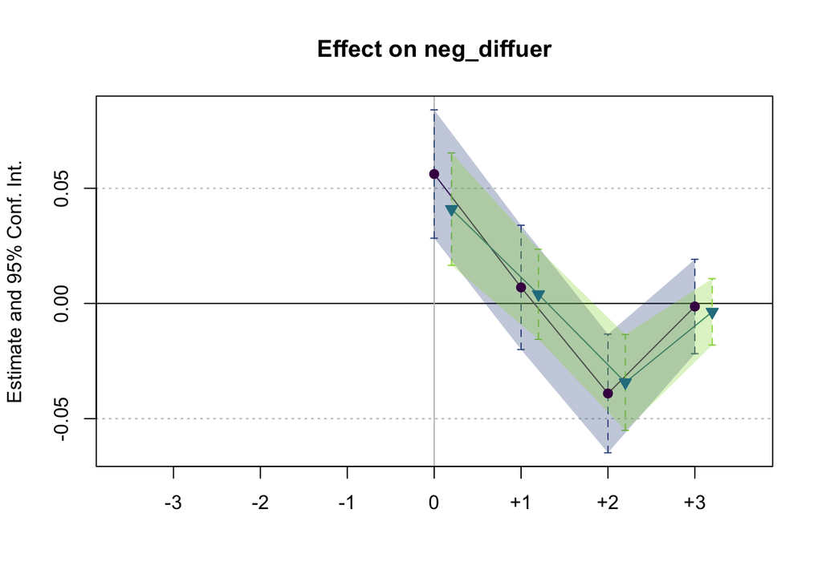

```r
fill_colors <- c(NA, "#39568CFF", "#95D840FF")
line_colors <- c(NA, "#440154FF", "#287D8EFF")
setFixest_coefplot(pt.join = TRUE, ci.join = FALSE, ci.fill = TRUE, ci.col = fill_colors,
                   pt.col = line_colors, pt.pch = c(0, 19, 25), pt.bg = line_colors,
                   pt.cex = 1, ci.fill.par = list(col = fill_colors, alpha = 0.3),
                   ci.lty = "dashed", ref.line = TRUE, ref.line.par = list(v = 4, col = "gray", lty = "solid"),
                   grid = TRUE, grid.par = list(vert = FALSE, lwd = 1), dict = plot_dict)

es_blank <- feols(diff_uer ~ l(mines_diff, -3:0) + lag_diff + lag_diff2 + lag_diff3 + diff_log_realgdp_pc |
               fips + year, allcomp_cc, panel.id = ~fips+year, se = 'twoway')

coefplot(list(es_3negcc, es3, es3_cc), drop = c('diff_log_realgdp_pc'), xlim.add = c(0,0.001))
```

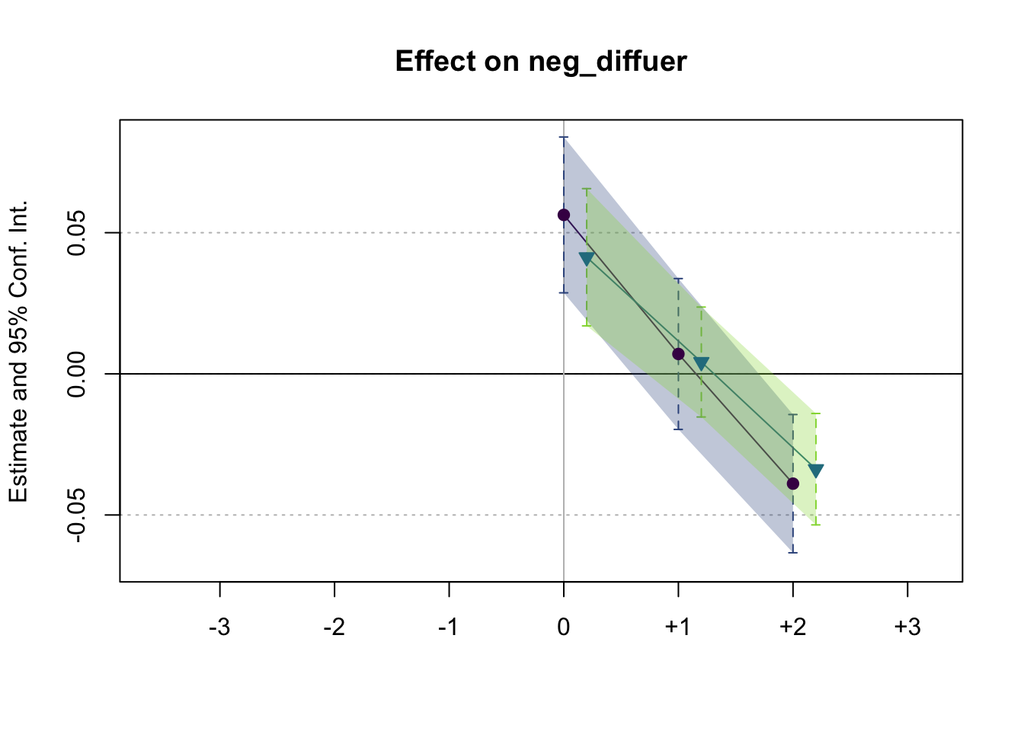

```r
coefplot(list(es_blank, es, es_cc), drop = c('diff_log_realgdp_pc'), xlim.add = c(0,0.001))
```

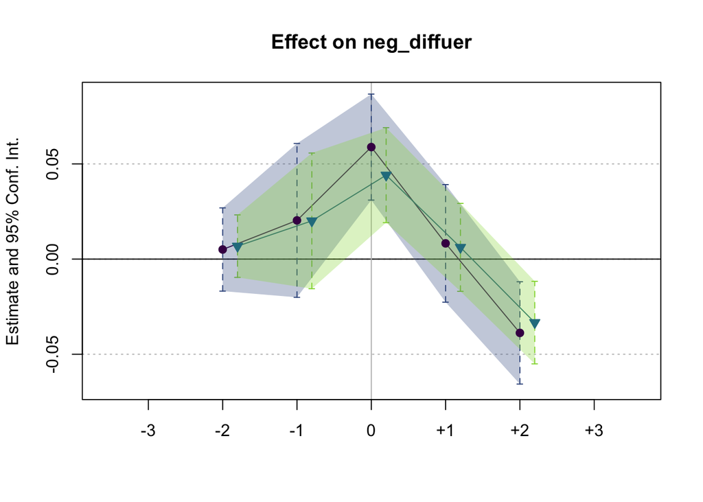

```r
coefplot(list(es_blank, es_2neg, es_2negcc), drop = c('diff_log_realgdp_pc'), xlim.add = c(0,0.06))
```

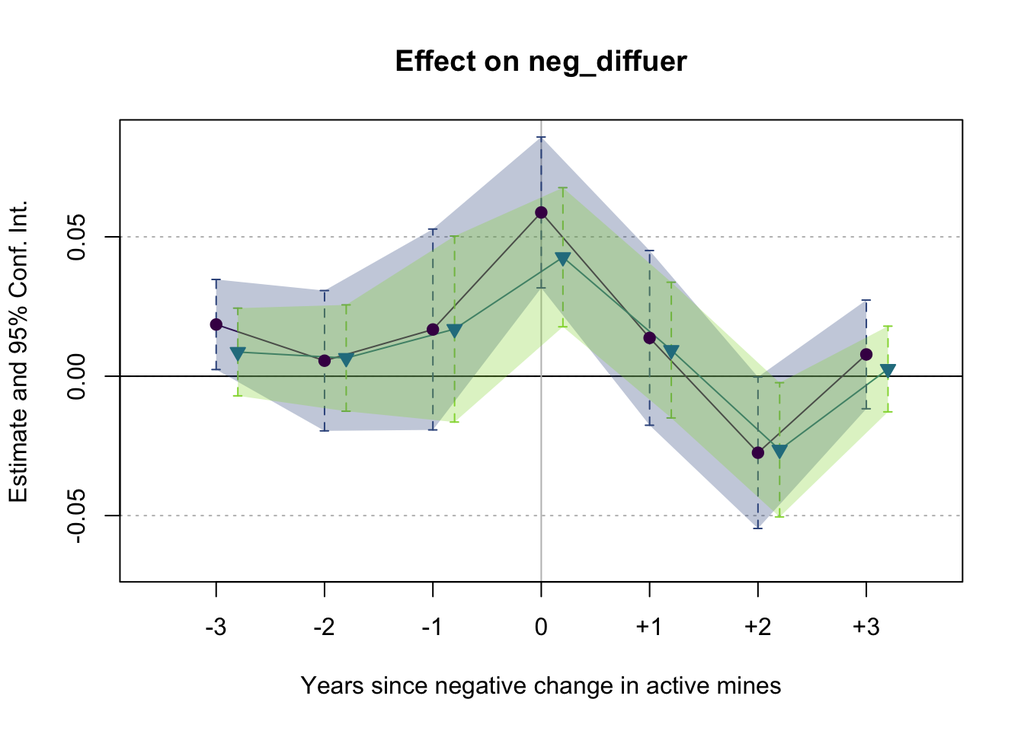

```r
coefplot(list(es_blank, es_3neg, es_3negcc), drop = c('diff_log_realgdp_pc'), xlab = "Years since negative change in active mines")
```

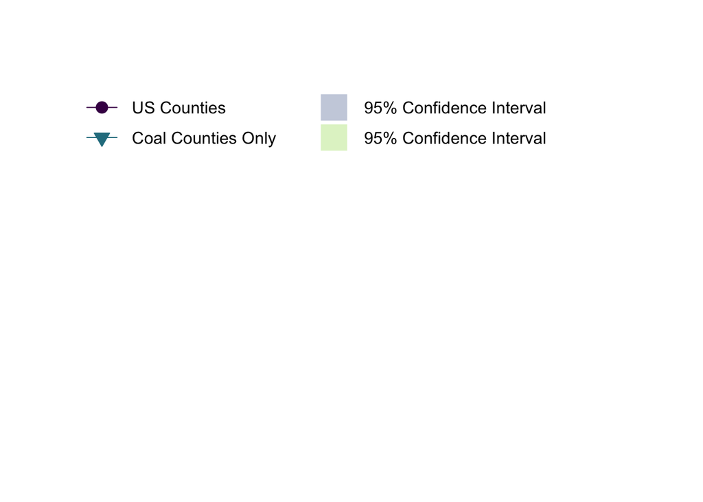

```r
plot(NULL ,xaxt='n',yaxt='n',bty='n',ylab='',xlab='', xlim=0:1, ylim=0:1)
legend("topleft", legend = c("US Counties", "Coal Counties Only", "95% Confidence Interval", "95% Confidence Interval"),
  col = c("#440154FF", "#287D8EFF", "#39568C4D", "#95D8404D"),
  pt.bg = c("#440154FF", "#287D8EFF", NA, NA),
  pch = c(19,25,15,15),
  bty = "n",
  pt.cex = c(1.5,1.5,3.5,3.5),
  cex = 1,
  text.col = "black",
  ncol = 2,
  lty = c("solid", "solid", NA, NA),
  y.intersp = 1.5
  )
```

### 2.0.1 Change in active mines interacted with rural (1) vs. urban (0)

*Research Question: Are changes in the amount of active mines associated with changes in the unemployment rate, conditional on whether a county is rural or not? Ie. do changes in active mines impact rural and urban counties differently?*

Results:

1. Models 6: Including rural = 1 interaction term does not add much information. Likely that an already small unemployment rate change disaggregated by county type weakens ability to detect an impact?

```r
# First (second) model uses set of all US counties (subset of coal counties only).

etable("Model 6_i" = feols(diff_uer ~ mines_diff + lag_diff + lag_diff2 +  mines_diff:ruc_bin + lag_diff:ruc_bin + lag_diff2:ruc_bin + diff_log_realgdp_pc |
               fips + year, allcomp, se = 'twoway'),
       "Model 6_i CC" = feols(diff_uer ~ mines_diff + lag_diff + lag_diff2 +  mines_diff:ruc_bin + lag_diff:ruc_bin + lag_diff2:ruc_bin + diff_log_realgdp_pc  |
               fips + year, allcomp_cc, se = 'twoway'))
```

### 2.0.2 Asymmetric treatment attempt

*Research Question: What is the impact of a positive (negative) change in active mines on county-level unemployment rate?*

The point estimates indicate a potential asymmetric treatment (mine closures lead to a larger change in unemployment rate as compared to the opening of a mine) effect but is not statistically significant.

Potential interesting result shows that the coefficient on change in mines is restricted to NEGATIVE changes. Essentially, this evidence shows that positive changes in active mines do not provide “windfall” employment, indicating that the solution is not to RETAIN or re-invigorate the mining sector.

```r
main <- feols(FE_diffuer, allcomp, se = 'twoway')
allcomp$pos_difflag <- ifelse(allcomp$lag_diff >= 0, 1, 0)
allcomp$pos_difflag2 <- ifelse(allcomp$lag_diff2 >= 0, 1, 0)
allcomp$neg_difflag <- ifelse(allcomp$lag_diff < 0, 1, 0)
allcomp$neg_difflag2 <- ifelse(allcomp$lag_diff2 < 0, 1, 0)

# Uses binary indicators for whether a change in active mines was positive (or zero)
# versus negative.
# Below uses set of all contiguous US counties
model_7_neg= feols(diff_uer ~ mines_diff + lag_diff + lag_diff2 + neg_diff:mines_diff +
                               neg_difflag:lag_diff + neg_difflag2:lag_diff2 + diff_log_realgdp_pc |
                               fips + year, allcomp, se = 'twoway')

model_8_pos = feols(diff_uer ~ mines_diff + lag_diff +lag_diff2 + pos_diff:mines_diff +
                               pos_difflag:lag_diff + pos_difflag2:lag_diff2 + diff_log_realgdp_pc |
                            fips + year, allcomp, se = 'twoway')

model_9_both = feols(diff_uer ~ neg_diff:mines_diff + neg_difflag:lag_diff + neg_difflag2:lag_diff2 + pos_diff:mines_diff + pos_difflag:lag_diff + pos_difflag2:lag_diff2 + diff_log_realgdp_pc | fips + year, allcomp, se = 'twoway')

etable(model_7_neg, model_8_pos, model_9_both, signifCode = c(`***` = 0.001, `**` = 0.01, `*` = 0.05, . = 0.1), tex = TRUE)
etable(model_9_both)

# Mines_diff is different from zero (statistically significant at the .1% level) (-0.056%)
glht(main, linfct = "mines_diff  = 0") %>% summary
glht(main, linfct = "mines_diff + lag_diff + lag_diff2 = 0") %>% summary

#glht(main, linfct = mcp(tension = c("mines_diff  = 0", "mines_diff + lag_diff + lag_diff2 = 0")))

# Mines_diff + mines_diff:neg_diff is different from zero (statistically significant at the 1% level)
# Higher coefficient value than in broader model (-0.078%)
glht(model_7_neg, linfct = "mines_diff + mines_diff:neg_diff = 0") %>% summary
glht(model_7_neg, linfct = "mines_diff + mines_diff:neg_diff + lag_diff + lag_diff:neg_difflag + lag_diff2 + lag_diff2:neg_difflag2 = 0") %>% summary

# Mines_diff and pos_diff is different from zero although not statistically significant and at a much lower magnitude! (-0.021%)
glht(model_8_pos, linfct = "mines_diff + mines_diff:pos_diff = 0") %>% summary
glht(model_8_pos, linfct = "mines_diff + mines_diff:pos_diff + lag_diff + lag_diff:pos_difflag + lag_diff2 + lag_diff2:pos_difflag2 = 0") %>% summary
```

### 2.0.3 Incorporating county types

The typology work is not included in this set of results. The following regressions take the set of 251 coal counties (as defined above) and subset into three groups depending on whether they are Type 1, 2, or 3 counties (see summary table in paper draft).

Results:

1. Main result is from CC Rural Model. Shows that the only type of county with statistically significant impacts from changes in active mines is the Type 1 rural, low-income, smaller, lower percentage of college education, lower female LFPR, etc. The effect detected here follows the same behavior as that in Model 1 and Model 1 CC.

```r
main <- feols(FE_diffuer, allcomp, se = 'twoway')
main_cc <- feols(FE_diffuer, allcomp_cc, se = 'twoway')

##### Run regressions from previous section incorporating the type of county. ########
# The county types (1,2,3) are derived from the clustering typology exercise outlined in the paper draft.
# Types are as follows: (rural:1; medium:2, urban:3)

cc_urbandf <- allcomp_cc_types %>% subset(type == 1)
cc_mediumdf <- allcomp_cc_types %>% subset(type == 2)
cc_ruraldf <- allcomp_cc_types %>% subset(type == 3)

cc_rural = feols(FE_diffuer, cc_ruraldf, se = "twoway")
cc_medium = feols(FE_diffuer, cc_mediumdf, se = "twoway")
cc_urban = feols(FE_diffuer, cc_urbandf, se = "twoway")

rural_2neg <- feols(diff_uer ~ l(mines_diff, -1:0) + lag_diff + lag_diff2 + lag_diff3 + diff_log_realgdp_pc |
               fips + year, cc_ruraldf, panel.id = ~fips+year, se = 'twoway')
medium_2neg <- feols(diff_uer ~ l(mines_diff, -1:0) + lag_diff + lag_diff2 + lag_diff3 + diff_log_realgdp_pc |
               fips + year, cc_mediumdf, panel.id = ~fips+year, se = 'twoway')
urban_2neg <- feols(diff_uer ~ l(mines_diff, -1:0) + lag_diff + lag_diff2 + lag_diff3 +diff_log_realgdp_pc |
               fips + year, cc_urbandf, panel.id = ~fips+year, se = 'twoway')


fill_colors <- c("#39568CFF", "#95D840FF", "#eb7134")
line_colors <- c("#440154FF", "#287D8EFF", "#eb7134")
setFixest_coefplot(pt.join = TRUE, pt.join.par = list(lwd = 2, lty = c("solid", "dashed", "dashed")),
                   ci.join = TRUE, ci.join.par = list(lty = c("dashed", "blank", "blank"), lwd = 0.5, col = line_colors), ci.fill = TRUE, ci.col = fill_colors,
                   pt.col = line_colors, pt.pch = c(25, 23, 19), pt.bg = line_colors,
                   pt.cex = 1, ci.fill.par = list(col = fill_colors, alpha = 0.1), ci.lwd = 0.5,
                   ci.lty = "blank", ref.line = TRUE, ref.line.par = list(v = 2, col = "gray", lty = "solid"),
                   grid = TRUE, grid.par = list(vert = FALSE, lwd = 1), dict = plot_dict, sep = 0)

coefplot(list(rural_2neg, medium_2neg, urban_2neg),drop = c('diff_log_realgdp_pc'), xlab = "Years since negative change in active mines")
legend("topright", legend = c("Type 1", "Type 2", "Type 3"), col = c( "#eb7134","#287D8EFF","#440154FF"), pt.bg= c( "#eb7134","#287D8EFF","#440154FF"), pch = c(19, 23, 25), cex = 1,
  text.col = "black", lty = c("dashed", "dashed", "solid"))

# coefplot(list(rural_2neg),drop = c('diff_log_realgdp_pc'))
# coefplot(list(medium_2neg),drop = c('diff_log_realgdp_pc'))
# coefplot(list(urban_2neg),drop = c('diff_log_realgdp_pc'))

etable("CC Urban" = cc_urban, "CC Medium" = cc_medium, "CC Rural" = cc_rural, urban_2neg, medium_2neg, rural_2neg, order = c("mines_diff,1", "Change Active Mines"))

 model_types <- list(
  "Rural Type 1 Counties" = cc_rural,
  "Medium Type 2 Counties" = cc_medium,
  "Urban Type 3 Counties" = cc_urban)


test <- allcomp_cc_types %>%
  group_by(fips) %>%
  summarize(m1 = length(unique(mines_diff)), m1mean = mean(mines_diff),
            m2 = length(unique(lag_diff)), m2mean = mean(lag_diff),
            m3 = length(unique(lag_diff2)), m3mean = mean(lag_diff2))

test2 <- subset(test, (m1 == 1 & m1mean == 0) | (m2 == 1 & m2mean == 0) | (m3 == 1 & m3mean == 0))
const_fips <- unique(test2$fips)
allcomp_pdmif <- subset(allcomp_cc_types, !(fips %in% const_fips))
removed <- subset(allcomp_cc_types, fips %in% const_fips)

# testagain includes only 15 counties
testagain <- filter(allcomp_cc_types, fips %in% const_fips) %>%
  group_by(fips) %>%
  summarize(mean = mean(active_mines), max = max(active_mines), min = min(active_mines))

means <- allcomp_cc_types %>%
  group_by(fips) %>%
  summarize(mean = mean(active_mines), max = max(active_mines), min = min(active_mines))

removed %>% select(fips, active_mines, mines_diff, lag_diff, lag_diff2) %>% View()
table(means$min)

etable("REE Model Rural" = feols(diff_uer ~ mines_diff + lag_diff + lag_diff2 + mines_diff:REE_bin_top90 +
                             lag_diff:REE_bin_top90 + lag_diff2:REE_bin_top90 + REE_bin_top90 + diff_log_realgdp_pc | fips + year, cc_ruraldf,  se = 'twoway'),
"REE Model Medium" = feols(diff_uer ~ mines_diff + lag_diff + lag_diff2 + mines_diff:REE_bin_top90 +
                             lag_diff:REE_bin_top90 + lag_diff2:REE_bin_top90 + REE_bin_top90 + diff_log_realgdp_pc | fips + year, cc_mediumdf,  se = 'twoway'),
            "REE Model Urban" = feols(diff_uer ~ mines_diff + lag_diff + lag_diff2 + mines_diff:REE_bin_top90 +
                             lag_diff:REE_bin_top90 + lag_diff2:REE_bin_top90 + REE_bin_top90 + diff_log_realgdp_pc | fips + year, cc_urbandf,  se = 'twoway'))


allcomp_cc %>%
  select(fips, year, diff_uer, mines_diff, lag_diff, lag_diff2, diff_log_realgdp_pc, type)

times <- c("mines_diff", "lag_diff", "lag_diff2")
glhts <- data.frame()
for(type in 1:3){
  for(t in times){
    v <- glht(test, linfct = paste0(t,"+`mines_diff:type == ",type,"` = 0")) %>%
      tidy %>% pull(estimate) %>% c(type, t, .)
    glhts <- rbind(glhts, v)
  }
}

test2 <- feols(diff_uer ~ mines_diff + lag_diff + lag_diff2 +
        diff_log_realgdp_pc | fips + year + type, allcomp_cc_types, se = "twoway")
```

```r
## Incorporating county types using PDMIF
# X can only have p columns where p = explanatory variables.

data4x <- select(allcomp_pdmif, c(mines_diff, lag_diff, lag_diff2, diff_log_realgdp_pc))
test <- as.matrix(data4x)
data4y <- select(allcomp_pdmif, c(year, fips, diff_uer))
yrs <- as.list(unique(data4y$year))
fps <- as.list(unique(data4y$fips))
data4y <- matrix(data = data4y$diff_uer, 18, 236, dimnames = list(yrs, fps))
groupmem <- allcomp_pdmif %>%
  group_by(fips) %>%
  summarize(type = unique(type))
groupmem <- data.frame(groupmem[,-1], row.names = groupmem$fips)

pdmif <- PDMIFLING(X = test, Y = data4y, Membership = groupmem, NGfactors = 1, NLfactors = c(2,2,2), Maxit = 30, tol = 0.01)

HYPTEST(pdmif$Coefficients,data.frame(c(0,1),c(-1,2)),pdmif$Se,"two",c(1,3),c(1,2))
dim(pdmif$Coefficients)
length(pdmif$GlobalFactors)
dim(pdmif$GlobalLoadings)
dim(pdmif$GroupFactors)
pdmif$GroupLoadings
pdmif$Coefficients
colnames(pdmif$Coefficients) <- colnames(data4y)

length(pdmif$Coefficients[1,which(groupmem$type == 3)])
length(pdmif$Coefficients[1,which(groupmem$type == 2)])
length(pdmif$Coefficients[1,which(groupmem$type == 1)])
pdmif$Coefficients[which(groupmem$type == 3)]

# pdmifshort <- pdmif$Coefficients[,colnames(pdmif$Coefficients)!="30003"]
# groupmemshort <- as.data.frame(groupmem[rownames(groupmem) != "30003",])
# names(groupmemshort) <- "type"

beeswarm(c(pdmif$Coefficients[1,],pdmif$Coefficients[2,],pdmif$Coefficients[3,]) ~ c(rep(1,236),rep(2,236), rep(3,236)),
          #col = c(rgb(0.25, 0.63, 1, 0.75), rgb(1, 0.88, 0.6, 0.75), rgb(0.97, 0.43, 0.37, 0.75)),
          pwcol = c(rep(groupmem$type), rep(groupmem$type),rep(groupmem$type)),
          pch=19, method="swarm", cex=0.5, corral="wrap", ylab="Value", xlab=NA, labels=c("mines_diff","lag_diff","lag_diff2"))

legend("topright", legend = c("1", "2", "3"),
       col = 1:3, pch = 19)

# allcomp %>% filter(fips == "30003") %>% ggplot(aes(y = uer, x = year))+
#   geom_line()+
#   geom_line(aes(y = mines_diff))


allcomp_cc_typespdmif <- subset(allcomp_cc_types, fips %in% allcomp_pdmif$fips)

urban_pdmif <- allcomp_cc_typespdmif %>% subset(type == 1)
medium_pdmif <- allcomp_cc_typespdmif %>% subset(type == 2)
rural_pdmif <- allcomp_cc_typespdmif %>% subset(type == 3)

cc_ruralpdmif = feols(FE_diffuer, rural_pdmif, se = "twoway")
cc_mediumpdmif = feols(FE_diffuer, medium_pdmif, se = "twoway")
cc_urbanpdmif = feols(FE_diffuer, urban_pdmif, se = "twoway")

etable(cc_rural, cc_ruralpdmif, cc_medium, cc_mediumpdmif, cc_urban, cc_urbanpdmif)
```

### 2.0.4 Binary change in mines

Likely to exclude this estimation as results are not significant.

```r
# ----- on binary indicator for whether the change in mines is negative from the previous year
allcomp$lag_closure2[which(is.na(allcomp$lag_closure2))] <- 0
allcomp_cc$lag_closure2[which(is.na(allcomp_cc$lag_closure2))] <- 0
etable("Model 10" = feols(diff_uer ~ mine_closure + lag_closure + lag_closure2 + diff_log_realgdp_pc | fips + year, allcomp, se = 'twoway'), "Model 11" = feols(diff_uer ~ mine_closure + lag_closure + lag_closure2 + mine_closure:ruc_bin +
               lag_closure:ruc_bin + lag_closure2:ruc_bin + diff_log_realgdp_pc | fips + year, allcomp, se = 'twoway'), "Model 10 CC" = feols(diff_uer ~ mine_closure + lag_closure + lag_closure2 + diff_log_realgdp_pc | fips + year, allcomp_cc, se = 'twoway'),"Model 11 CC" = feols(diff_uer ~ mine_closure + lag_closure + lag_closure2 + mine_closure:ruc_bin +
               lag_closure:ruc_bin + lag_closure2:ruc_bin + diff_log_realgdp_pc | fips + year, allcomp_cc, se = 'twoway'))
```

### 2.0.5 Change in coal production

Likely to exclude this estimation as results are not significant.

# 3 Overall Economy Model

Coefficient interpretation….mines_diff impact on CHANGE in UER and CHANGE in LOG of emp, unemp, lf, and pop. Does this mean that the coefficient on mines_diff translates to “a one-unit increase in mines is correlated with a x% increase in the CHANGE in log of emp, unemp, lf and pop.”

Isn’t the question we want to answer the impact of mines_diff on the log of emp, unemp, lf, pop? Or are we comparing the change in the CHANGE in log of emp, etc compared to mean change?

```r
model_uer <- feols(FE_diffuer, allcomp, se = 'twoway')
model_emp <- feols(diff_log_employed ~ mines_diff + lag_diff + lag_diff2 + diff_log_realgdp + diff_log_pop | fips + year, allcomp, se = 'twoway')
model_unemp <- feols(diff_log_unemployed ~ mines_diff + lag_diff + lag_diff2 + diff_log_realgdp + diff_log_pop | fips + year, allcomp, se = 'twoway')
model_lf <- feols(diff_log_lf ~ mines_diff + lag_diff + lag_diff2 + diff_log_realgdp + diff_log_pop |
               fips + year, allcomp, se = 'twoway')
model_pop <- feols(diff_log_pop ~ mines_diff + lag_diff + lag_diff2 + diff_log_realgdp |
               fips + year, allcomp, se = 'twoway')

model_uercc <- feols(FE_diffuer, allcomp_cc, se = 'twoway')
model_empcc <- feols(diff_log_employed ~ mines_diff + lag_diff + lag_diff2 + diff_log_realgdp + diff_log_pop | fips + year, allcomp_cc, se = 'twoway')
model_unempcc <- feols(diff_log_unemployed ~ mines_diff + lag_diff + lag_diff2 + diff_log_realgdp + diff_log_pop | fips + year, allcomp_cc, se = 'twoway')
model_lfcc <- feols(diff_log_lf ~ mines_diff + lag_diff + lag_diff2 + diff_log_realgdp + diff_log_pop |
               fips + year, allcomp_cc, se = 'twoway')
model_popcc <- feols(diff_log_pop ~ mines_diff + lag_diff + lag_diff2 + diff_log_realgdp |
               fips + year, allcomp_cc, se = 'twoway')


etable("Model 1"= model_uer,
       "Model 2" = model_emp,
       "Model 3" = model_unemp,
       "Model 4" = model_lf,
       "Model 5" = model_pop)

# Performs same regressions on subset of coal counties only (defined as counties
# that have had active mines between 2002-2019).
etable("Model 1 CC"= model_uercc,
       "Model 2 CC" = model_empcc,
       "Model 3 CC" = model_unempcc,
       "Model 4 CC" = model_lfcc,
       "Model 5 CC" = model_popcc)

model_list = list(model_uer, model_emp, model_unemp, model_lf, model_pop)
var_rows <-  c("Dependent Var.:", "Change Active Mines","Change Active Mines (t-1)","Change Active Mines (t-2)")

# econ_df <- data.frame(matrix(nrow = 4))
# for(k in 1:length(model_list)){
#   model = etable(model_list[k])
#   save_short <- subset(model, rownames(model) %in% var_rows)
#   econ_df <- cbind(econ_df, save_short)
# }
# econ_df
# test <- as.matrix(pvalue(model_emp)[1:3])

econ_df <- as.data.frame(rbind(create_cols(model_uer), create_cols(model_emp), create_cols(model_unemp), create_cols(model_lf), create_cols(model_pop)))
colnames(econ_df) <- c("t", "t-1", "t-2")
econ_df$model <- c("UER", "EMP", "UNEMP", "LF", "POP")
econ_dflong <- pivot_longer(econ_df, !model, names_to = "time", values_to = "fill")
#econ_dflong$fill <- as.factor(econ_dflong$fill)
econ_dflong$fill[which(econ_dflong$fill == 0)] <- NA
# writexl::write_xlsx(econ_dflong, here("data/"fulleconomydf.xlsx"))
ggplot(econ_dflong, aes(x = time, y = model, fill = fill))+
  scale_y_discrete(limits = rev(c("UER", "EMP", "UNEMP", "LF", "POP")), labels = rev(c("Model 1: \u0394 UER","Model 2: \u0394 (log) Employed persons", "Model 3: \u0394 (log) Unemployed persons", "Model 4: \u0394 (log) Labor force", "Model 5: \u0394 (log) Population")))+
  scale_x_discrete(limits = c("t", "t-1", "t-2"), labels = c("0","+1", "+2"))+
    geom_tile(color = "white",
            lwd = 1.5,
            linetype = 1)+
  scale_fill_gradientn(colours=c("navy","royalblue","lightskyblue","white", "mistyrose","red", "darkred"),limits = c(-4,4), na.value = "grey98", labels = c("(-)***","(-)**", "(+/-)*", "(+)**","(+)***"),labs(colour="Sign and Significance Level", size = 0.1))+
  ylab("Outcome Variable")+
  xlab("# years following mine closure")+
  theme(panel.background = element_blank(), panel.border = element_blank(), legend.title=element_text(size=8), )
ggsave("economy_model.jpg")

ggplot(econ_dflong, aes(x = time, y = model, fill = fill))+
  scale_y_discrete(limits = rev(c("UER", "EMP", "UNEMP", "LF", "POP")), labels = rev(c("\u0394 UER","\u0394 (log) Employed persons", "\u0394 (log) Unemployed persons", "\u0394 (log) Labor force", "\u0394 (log) Population")))+
  scale_x_discrete(limits = c("t", "t-1", "t-2"), labels = c("0","1", "2"))+
    geom_tile(color = "white",
            lwd = 1.5,
            linetype = 1)+
  scale_fill_gradientn(colours=c("navy","royalblue","lightskyblue","white", "mistyrose","red", "darkred"),limits = c(-4,4), na.value = "grey98", labels = c("(-)***","(-)**", "(+/-)*", "(+)**","(+)***"),labs(colour="Sign and Significance Level", size = 0.1))+
  ylab("Outcome Variable")+
  xlab("# years following mine closure")+
  theme(panel.background = element_blank(), panel.border = element_blank(), legend.title=element_text(size=8), )
```

## 3.1 Effect of REE investments:

*Research Question: Do proximate renewable energy investments impact county-level employment impacts of mine closures?*

Results: 1. No statistically significant impact of renewable energy investments detected.

```r
summary(allcomp$REE_inv_scaled_realgdp[allcomp$REE_inv_scaled_realgdp != 0])

#7728 observations of non-zero REE. 13.9% of observations have non-zero REE
# 460 observations have investment >= 1*county real GDP (8 also with active mines)
# 75 observations have investment >= 10*county real GDP
# 6 observations have investment >= 100*county real GDP
# 1st quartile upper limit is 0.0049* county real GDP

### 465 observations in coal subset with 162 with mines_diff != 0
test <- subset(allcomp, REE_inv_scaled_realgdp != 0)
quantile(test$REE_inv_scaled_realgdp, probs = seq(.1, .9))
summary(test$REE_inv_scaled_realgdp)
hist(test$REE_inv_scaled_realgdp[test$REE_inv_scaled_realgdp < 1], breaks = 100)

##### Preferable to use indicator for whether ANY REE as only 162 observations?
##### (of 7728 with REE investments) have non-zero mines_diff
## Went with top 10th percentile of data (7020 observations 152 with non-zero mines_diff)

ree_model_main = feols(diff_uer ~ mines_diff + lag_diff + lag_diff2 + mines_diff:REE_bin_top90 +
                             lag_diff:l(REE_bin_top90,1) + lag_diff2:l(REE_bin_top90,2) +  REE_bin_top90 + l(REE_bin_top90,1) + l(REE_bin_top90,2) + diff_log_realgdp_pc | fips + year, allcomp, panel.id = ~fips+year,  se = 'twoway')

ree_model_test = feols(diff_uer ~ mines_diff + lag_diff + lag_diff2 + mines_diff:REE_bin_top90 +
                             lag_diff:lag_ree + lag_diff2:lag_ree2 +  REE_bin_top90 + lag_ree + lag_ree2 + diff_log_realgdp_pc | fips + year, tester, panel.id = ~fips+year,  se = 'twoway')

etable(ree_model_main, ree_model_test)

etable("REE Model Main" = ree_model_main,
       "REE Model CC" = feols(diff_uer ~ mines_diff + lag_diff + lag_diff2 + mines_diff:REE_bin_top90 +
                             lag_diff:l(REE_bin_top90,1) + lag_diff2:l(REE_bin_top90,2) +  REE_bin_top90 + l(REE_bin_top90,1) + l(REE_bin_top90,2) + diff_log_realgdp_pc | fips + year, allcomp_cc, panel.id = ~fips+year, se = 'twoway'), signifCode = c(`***` = 0.001, `**` = 0.01, `*` = 0.05, . = 0.1), tex = TRUE)



etable(feols(diff_uer ~ mines_diff + mines_diff:REE_bin_top90 + mines_diff:l(REE_bin_top90, 1) + mines_diff:l(REE_bin_top90, 2) + diff_log_realgdp_pc | fips + year, allcomp, panel.id = ~fips+year,se = 'twoway'),
       feols(diff_uer ~ mines_diff + mines_diff:REE_bin_top90 + diff_log_realgdp_pc | fips + year, allcomp, panel.id = ~fips+year,se = 'twoway'),
       feols(diff_uer ~ mines_diff + mines_diff:l(REE_bin_top90, 1) + diff_log_realgdp_pc | fips + year, allcomp, panel.id = ~fips+year,se = 'twoway'),
       feols(diff_uer ~ mines_diff + mines_diff:l(REE_bin_top90, 2) + diff_log_realgdp_pc | fips + year, allcomp, panel.id = ~fips+year,se = 'twoway'))

etable(feols(diff_uer ~ lag_diff2 + diff_log_realgdp_pc | fips + year, allcomp, panel.id = ~fips+year,se = 'twoway'),
       feols(diff_uer ~ lag_diff2 + lag_diff2:l(REE_bin_top90, 1) + diff_log_realgdp_pc | fips + year, allcomp, panel.id = ~fips+year,se = 'twoway'),
       feols(diff_uer ~ lag_diff2 + lag_diff2:l(REE_bin_top90, 2) + diff_log_realgdp_pc | fips + year, allcomp, panel.id = ~fips+year,se = 'twoway'),
       feols(diff_uer ~ lag_diff2 + lag_diff2:l(REE_bin_top90, 2) + lag_diff2:l(REE_bin_top90, 1) + diff_log_realgdp_pc | fips + year, allcomp, panel.id = ~fips+year,se = 'twoway'), signifCode = c(`***` = 0.001, `**` = 0.01, `*` = 0.05, . = 0.1))
```

# 4 Spatial models

## 4.1 Spatial models

### 4.1.1 Tests for cross-sectional dependence

Cross-sectional dependence detected. Moran’s I test and lagrange multiplier tests remain to be run!

```r
##############################################################
# library(lmtest)
# mainplm <- plm(diff_uer ~ mines_diff + lag_diff + lag_diff2 + diff_log_realgdp_pc, allcomp_full, effect="twoways", index = c("fips","year"))

# Confirms fixed effects is the way to go
phtest(diff_uer ~ mines_diff + lag_diff + lag_diff2 + diff_log_realgdp_pc,
        data = allcomp_full, effect = "twoways", index = c("fips", "year"),
        test = c("cd", "sclm", "bcsclm", "lm", "rho", "absrho"),
        w = fmat)

# Confirms presence of cross sectional dependence
tests <- c("cd", "lm", "sclm", "rho", "absrho")

cdtest <- lapply(tests,function(x) pcdtest(diff_uer ~ mines_diff + lag_diff + lag_diff2 + diff_log_realgdp_pc,
        data = allcomp_full, effect = "twoways", index = c("fips", "year"),
        test = x,
        w = fmat))

pcdtest(diff_uer ~ mines_diff + lag_diff + lag_diff2 + diff_log_realgdp_pc,
        data = allcomp_full, effect = "twoways", index = c("fips", "year"),
        test = "rho",
        w = fmat)

# Randomization-based test of spatial dependence for panel models
# All of the following confirm cross-sectional dependence robust to global
# dependence by common factors and persistence (serial correlation) in the data (Millo 2017)
#"rho" for the average correlation coefficient
# These return identical results...why?

rwtest(diff_uer ~ mines_diff + lag_diff + lag_diff2 + diff_log_realgdp_pc,
        data = allcomp_full, test = "rho", w = fmat, effect = "twoways", index = c("fips", "year"))
# "cd" for Pesaran's CD statistic
rwtest(diff_uer ~ mines_diff + lag_diff + lag_diff2 + diff_log_realgdp_pc,
        data = allcomp_full, test = "cd", w = fmat, effect = "twoways", index = c("fips", "year"))

# "sclm" for the scaled version of Breusch and Pagan's LM statistic,
rwtest(diff_uer ~ mines_diff + lag_diff + lag_diff2 + diff_log_realgdp_pc,
        data = allcomp_full, test = "sclm", w = fmat, effect = "twoways", index = c("fips", "year"))


# Below not required
#
# sphtest(diff_uer ~ mines_diff + lag_diff + lag_diff2 + diff_log_realgdp_pc, data = allcomp_full, effect = "twoways", listw = fmatlw, spatial.model = "error", method = "ML")
# sphtest(diff_uer ~ mines_diff + lag_diff + lag_diff2 + diff_log_realgdp_pc, data = allcomp_full, effect = "twoways", listw = fmatlw, spatial.model = "lag", method = "ML")
# sphtest(diff_uer ~ mines_diff + lag_diff + lag_diff2 + diff_log_realgdp_pc, data = allcomp_full, effect = "twoways", listw = fmatlw,spatial.model = "sarar",method = "ML")


# MORAN'S I TEST
#moran.lm<-lm.morantest(allcomp_full$diff_uer, fmatlw, alternative="two.sided")


# Vetor memory exhausted
# LAGRANGE MULTIPLIER TEST
# Locally robust LM tests for spatial lag (error) correlation sub spatial error (lag) correlation in panel models
#slmtest(diff_uer ~ mines_diff + lag_diff + lag_diff2 + diff_log_realgdp_pc,
#        data = allcomp_full, listw = fmatlw, test="lme", model="within")
#slmtest(diff_uer ~ mines_diff + lag_diff + lag_diff2 + diff_log_realgdp_pc,
#        data = allcomp_full, listw = fmatlw, test="lml", model="within")
#slmtest(diff_uer ~ mines_diff + lag_diff + lag_diff2 + diff_log_realgdp_pc,
#        data = allcomp_full, listw = fmatlw, test="rlme", model="within")
#slmtest(diff_uer ~ mines_diff + lag_diff + lag_diff2 + diff_log_realgdp_pc,
#        data = allcomp_full, listw = fmatlw, test="rlml", model="within")
```

```r
# This does not include 7 LA counties for which no employment indicators
# were recorded in 2005 and 2006. Therefore, use allcomp_full as created
# in the spatial matrix initiation section.

# Broomfield County, Colorado was only created in 2001 so no observation
# exists for 2001 - will replace with 0 for completeness. It is only the
# first observation...

allcomp_full$diff_log_realgdp_pc[which(allcomp_full$fips == "08014" & allcomp_full$year == 2002)] <- 0
allcomp_full$diff_log_realgdp[which(allcomp_full$fips == "08014" & allcomp_full$year == 2002)] <- 0
allcomp_full$diff_log_pop[which(allcomp_full$fips == "08014" & allcomp_full$year == 2002)] <- 0

fmdiff_uer <- diff_uer ~ mines_diff + lag_diff + lag_diff2 + diff_log_realgdp_pc

# Required to extract Log Likelihood of error and SARAR model
#fixInNamespace("spsararlm", "splm")
#fixInNamespace("sperrorlm", "splm")
# (NOT DONE AS SPLAGLM RETURNS A MEASURE FOR LL)
#fixInNamespace("splaglm", "splm")
# This third function (which returns a value for loglikelihood, transforms it according to:
# ens <- as.numeric((time * ldet  - ((n*time/2) * log(2 * pi)) - (n*time/2) * log(s2) - 1/(2 * s2) * SSE))
# and then returns ens instead of LL.......

#And manually add "ll=LL" as an element to the "return" list at the end of
#the function so that it reads:
#return <- list(coeff = betas, lambda = lambda, s2 = s2, rest.se = rest.se,
#       lambda.se = lambda.se, asyvar1 = asyvar1, ll=LL)

sp_err_mines <- spml(fmdiff_uer, allcomp_full,
                     index = NULL,  listw = fmatlw, lag = FALSE, na.action = na.fail,
                     spatial.error = "b",  model = "within", effect = "twoways", quiet = FALSE)


sp_lag_mines <- spml(fmdiff_uer, allcomp_full, index = NULL,  listw = fmatlw,
                     lag = TRUE, na.action = na.fail,
                     spatial.error = "none",  model = "within", effect = "twoways", quiet = FALSE)


# Only used to test whether unadjusted loglikelihood yields different AIC and BIC results
# sp_lag_mines_unadjll <- spml(fmdiff_uer, allcomp_full, index = NULL,  listw = fmatlw,
#                      lag = TRUE, na.action = na.fail,
#                      spatial.error = "none",  model = "within", effect = "twoways", quiet = FALSE)

sp_err_lag_mines <- spml(fmdiff_uer, data = allcomp_full, index = NULL,  listw = fmatlw,
                         lag = TRUE, na.action = na.fail, spatial.error = "b",
                         model = "within", effect = "twoways", quiet = FALSE)


# sp_err_mines$logLik
# sp_lag_mines$logLik
# sp_lag_mines_unadjll$logLik
# sp_err_lag_mines$logLik

# summary(sp_err_mines)
# summary(sp_lag_mines)
# summary(sp_lag_mines_unadjll)
# summary(sp_err_lag_mines)

sparse.W <- listw2dgCMatrix(fmatlw)
time <- length(unique(allcomp_full$year))
s.lwcounties <- kronecker(Matrix::Diagonal(time), sparse.W)
trMatc <- spatialreg::trW(s.lwcounties, type="mult")
implag <- spatialreg::impacts(sp_lag_mines, tr = trMatc, R = 200)
imperrlag <- spatialreg::impacts(sp_err_lag_mines, tr = trMatc, R = 200)

summary(sp_err_mines)
summary(implag, zstats=TRUE, short=TRUE)
summary(imperrlag, zstats=TRUE, short=TRUE)

mainfull <- feols(FE_diffuer, allcomp_full, se = 'twoway')
merged <- allcomp_full %>%
   mutate(residuals_lag = residuals(sp_lag_mines), residuals_lagerr = residuals(sp_err_lag_mines), residuals_err = residuals(sp_err_mines), residuals_main = residuals(mainfull))

#moran.mc(merged$residuals_lag, listw = fmatlw, 1000, zero.policy = TRUE)

for(i in 2002:2019){
  print(moran.mc(merged$residuals_lag[which(merged$year == i)], listw = fmatlw, 1000, zero.policy = TRUE))
}

mergedp <- pdata.frame(merged, index = c("fips", "year"))

# PCD cross-sectional dependence of residuals:
# Main: reject independence: p-value: 2.2e-16
# rho: 0.0047673
----
# SAR: reject independence: p-value: 0.01644
# rho: -0.00026
----
# SLM: reject independence: p-value: 0.036
# rho: -0.00027
----
# SARAR: reject independence: p-value: 0.0425
# rho: -0.00022
res <- c('residuals_main', 'residuals_err', 'residuals_lag', 'residuals_lagerr')
res_table <- data.frame()
for(m in res){
  for(t in c("cd", "rho")){
  test <- mergedp %>% pull(m) %>%
    pcdtest(test = t) %>% tidy %>%
    cbind(Model = m,.)
    res_table <- bind_rows(res_table, test)
  }
}
kable(res_table, format = "latex")

ssr_spatial <- merged %>%
  group_by(fips) %>%
  summarise(ssr_err = sum(residuals_err^2), ssr_lag = sum(residuals_lag^2), ssr_errlag = sum(residuals_lagerr^2), ssr_main = sum(residuals_main^2))

moran.mc(ssr_spatial$ssr_main, listw = fmatlw, 1000, zero.policy = TRUE)
moran.mc(ssr_spatial$ssr_err, listw = fmatlw, 1000, zero.policy = TRUE)
moran.mc(ssr_spatial$ssr_lag, listw = fmatlw, 1000, zero.policy = TRUE)
moran.mc(ssr_spatial$ssr_errlag, listw = fmatlw, 1000, zero.policy = TRUE)

ssr_spatial <- df_va(ssr_spatial)

for (i in 1:length(names(ssr_spatial)[-1])){
  mod = names(ssr_spatial[i+1])
  k <- plot_usmap(data = ssr_spatial, values = mod, regions = "counties", col = "black", size = 0.07, exclude = c("AK", "HI" )) +
  labs(title = paste0("Geographical Distribution of SSR in ",mod,"model")) +
  scale_fill_viridis(name = "ssr",  na.value = "seashell2") +
  theme(panel.background = element_rect(colour = "black", fill = "gray90"))
  print(k)
}
```

```r
sp_err <- dw_compat(sp_err_mines)
sp_lag_direct <- dw_compat_direct(implag)
sp_lag_indirect <- dw_compat_indirect(implag)
sp_lag_direct$model <- "SLM Direct"
sp_lag_indirect$model <- "SLM Indirect"

sp_errlag_direct <- dw_compat_direct(imperrlag)
sp_errlag_indirect <- dw_compat_indirect(imperrlag)
sp_errlag_direct$model <- "SARAR Direct"
sp_errlag_indirect$model <- "SARAR Indirect"

spat_models <- rbind(sp_err[2:4,], sp_lag_direct[1:3,],sp_errlag_direct[1:3,])

# Spatial Durbin model here!
# library(spatialreg)
# lagsarlm(fmdiff_uer, allcomp_LA, listw = fmatlw, na.action = na.fail, Durbin = TRUE)
```

### 4.1.2 Employed overall

```r
fmdiff_employed <- diff_log_employed ~ mines_diff + lag_diff + lag_diff2 + diff_log_realgdp + diff_log_pop

emp_spat <- spml(fmdiff_employed, data = allcomp_full, index = NULL,  listw = fmatlw,
                         lag = TRUE, na.action = na.fail, spatial.error = "b",
                         model = "within", effect = "twoways", quiet = FALSE)


impemp_spat <- spatialreg::impacts(emp_spat, tr = trMatc, R = 200)
summary(impemp_spat, zstats=TRUE, short=TRUE)
```

### 4.1.3 Unemployed spatial

```r
fmdiff_unemp <- diff_log_unemployed ~ mines_diff + lag_diff + lag_diff2 + diff_log_realgdp + diff_log_pop

unemp_spat <- spml(fmdiff_unemp, data = allcomp_full, index = NULL,  listw = fmatlw,
                         lag = TRUE, na.action = na.fail, spatial.error = "b",
                         model = "within", effect = "twoways", quiet = FALSE)

imp_unemp_spat <- spatialreg::impacts(unemp_spat, tr = trMatc, R = 200)
summary(imp_unemp_spat, zstats=TRUE, short=TRUE)
```

### 4.1.4 Labour force spatial

```r
fmdiff_lf <- diff_log_lf ~ mines_diff + lag_diff + lag_diff2 + diff_log_realgdp + diff_log_pop
lf_spat <- spml(fmdiff_lf, data = allcomp_full, index = NULL,  listw = fmatlw,
                         lag = TRUE, na.action = na.fail, spatial.error = "b",
                         model = "within", effect = "twoways", quiet = FALSE)

imp_lf_spat <- spatialreg::impacts(lf_spat, tr = trMatc, R = 200)
summary(imp_lf_spat, zstats=TRUE, short=TRUE)
```

### 4.1.5 Population spatial

```r
fmdiff_pop <- diff_log_pop ~ mines_diff + lag_diff + lag_diff2 + diff_log_realgdp
pop_spat <- spml(fmdiff_pop, data = allcomp_full, index = NULL,  listw = fmatlw,
                         lag = TRUE, na.action = na.fail, spatial.error = "b",
                         model = "within", effect = "twoways", quiet = FALSE)

imp_pop_spat <- spatialreg::impacts(pop_spat, tr = trMatc, R = 200)
summary(imp_pop_spat, zstats=TRUE, short=TRUE)
```

### 4.1.6 Table of calculated impacts of overall economy spatial models (SARAR)

```r
tab2 <- cbind(spat_output(impemp_spat)[-4],
      spat_output(imp_unemp_spat)[-4],
      spat_output(imp_lf_spat)[-4],
      spat_output(imp_pop_spat)[-4])

kable(tab2[,1:6], booktabs=TRUE, format = "latex") %>%
  add_header_above(setNames(c("", 3, 3), c("", "Employed Persons", "Unemployed Persons"))) %>%
  kable_styling(position="center")

kable(tab2[,7:12], booktabs=TRUE, format = "latex") %>%
  add_header_above(setNames(c("", 3, 3), c("", "Labour Force", "Population"))) %>%
  kable_styling(position="center")
```

# 5 (Potential) useful figures/maps

### 5.0.1 SSR

Don’t see immediate cause for concern? Perhaps some clustering in the southwest/appalachia but the counties themselves are also smaller in size so might optically trick?

```r
glht(main, linfct = "mines_diff + lag_diff + lag_diff2 = 0") %>% summary
glht(main_cc, linfct = "mines_diff + lag_diff + lag_diff2 = 0") %>% summary

ssr_df <- allcomp %>% slice(main$obs_selection$obsRemoved) %>% mutate(residuals = main$residuals) %>%
  group_by(fips) %>%
  summarise(ssr = sum(residuals^2))

allcompva <- df_va(allcomp)

ssr_df_va <- df_va(ssr_df)
plot_usmap(data = ssr_df_va, values = "ssr", regions = "counties", col = "black", size = 0.07, exclude = c("AK", "HI" )) +
  labs(title = "Geographical Distribution of SSR") +
  scale_fill_viridis(name = "ssr",  na.value = "seashell2") +
  theme(panel.background = element_rect(colour = "black", fill = "gray90"))

hist(ssr_df$ssr)
```

### 5.0.2 UER

```r
means_overall <- allcomp %>%
   group_by(fips) %>%
   summarize(uer = mean(uer), REE_scaled = sum(REE_inv_scaled_realgdp))

means_overallva <- df_va(means_overall)

hist(allcompva$mines_diff[allcompva$mines_diff != 0])
summary(allcompva$mines_diff[allcompva$mines_diff != 0])

plot_usmap(data = filter(allcompva, year == 2019), values = "uer", regions = "counties", col = "black", size = 0.07, exclude = c("AK", "HI" )) +
   labs(title = "Geographical Distribution of Unemployment Rate in 2019") +
   scale_fill_viridis(name = "uer", na.value = "seashell2", direction = -1, option = "magma") +
   theme(panel.background = element_rect(color = "black", fill = "gray90"), legend.position = "left")
```

### 5.0.3 UER over time

This would ideally be animated or grid arranged but have not yet figured it out :)

```r
# Goal: animate or grid.arrange
uer_list = list()
for(i in 2002:2019){
   j = i - 2001
   p1 <- plot_usmap(data = filter(allcompva, year == i), values = "uer", regions = "counties", col = "black", size = 0.07, exclude = c("AK", "HI" )) +
     labs(title = paste0("Geographical Distribution of Unemployment Rate in ", i)) +
     scale_fill_viridis(name = "uer",  na.value = "seashell2", direction = -1) +
     theme(panel.background = element_rect(color = "black", fill = "gray90"), legend.position = "left")
   print(p1)
   uer_list[[j]] <- p1
}
```

### 5.0.4 Other indicators over time

```r
yearsums <- allcomp %>%
  group_by(year) %>%
  summarize(REE = sum(REE_inv), TAA = sum(total_taa), active_mines = sum(active_mines),
            mines_diff = sum(mines_diff), uer = mean(uer), emp = sum(emp),
            employed = sum(employed), unemployed = sum(unemployed),
            labour_force = sum(labour_force), labor_hours = mean(labor_hours, na.rm = TRUE))

yearsums$uercalc <- (yearsums$unemployed/yearsums$labour_force)*100

reeplot <- ggplot(yearsums, aes(x=year, y=REE)) +
  geom_line()+
  geom_point()+
  labs(title="Renewable energy investments between 2002-2019",x="Year", y = "Renewable Energy Investments")+
  scale_color_viridis(option = "D") +
  scale_fill_viridis(option = "D")

taaplot <- ggplot(yearsums, aes(x=year, y=TAA)) +
  geom_line()+
  geom_point()+
  labs(title="TAA funding between 2002-2019",x="Year", y = "Renewable Energy Investments")

mines_diffplot <- ggplot(yearsums, aes(x=year, y=mines_diff)) +
  geom_line()+
  geom_line(linetype = "dashed", aes(y = 0))+
  geom_point()+
  labs(title="Change in active mines between 2002-2019",x="Year", y = "Change in active mines")

mines_diff_cty <- ggplot(allcomp, aes(x=year, y = mines_diff)) +
  geom_jitter(aes(color = state.x))+
  geom_point(aes(y = max(mines_diff)))+
  labs(title="Change in active mines between 2002-2019",x="Year", y = "Change in active mines")


emp_lfplot <- ggplot(yearsums, aes(x = year)) +
  geom_line(aes(y = employed, color = "Employed persons")) +
  geom_line(aes(y = labour_force, color = "Labour force"))+
  theme(legend.position = "bottom")+
  labs(title="Employed, Labour Force",x="Year")

unemp_plot <- ggplot(yearsums, aes(x = year, y = labour_force)) +
  geom_line(aes(y = labour_force, color = "Labour force"))+
  theme(legend.position = "bottom")+
  labs(title="Unemployed Persons",x="Year")

uerplot <-ggplot(yearsums, aes(x = year, y = uercalc)) +
  geom_line()+
  theme(legend.position = "bottom")+
  labs(title="National unemployment rate",x="Year")

mines_emp <- ggplot(yearsums, aes(x = year)) +
  geom_line(aes(y = active_mines, color = "Active Mines")) +
  geom_line(aes(y = emp/100, color = "Persons Employed in Coal")) +
  scale_y_continuous(
    name = "Active Mines",
    sec.axis = sec_axis(~.*100, name="Persons Employed in Coal (Hundreds)")
  ) +
  theme(legend.position = "bottom",
    legend.title = element_blank(),
    axis.title.y = element_text(size=13, face = "italic", hjust = 0.5),
    axis.title.y.right = element_text(size=13, face = "italic", hjust = 0.5),
    title = element_text(size = 12)
  ) +
  scale_color_viridis(discrete = TRUE, direction = -1)

grid.arrange(reeplot, taaplot, mines_diffplot, mines_emp, ncol=2, nrow =2)
grid.arrange(uerplot, emp_lfplot, unemp_plot, ncol=2, nrow =2)
```

# 6 Interactive Fixed Effects/Factor Structure Efforts

## 6.1

### 6.1.1 Testing for presence of unobserved common factors

Confirmed!

```r
library(phtt)

# Create matrices of most often used variables
dep_diff_uer <- c_mat(allcomp$diff_uer)
ind_mines_diff <- c_mat(allcomp$mines_diff)
ind_lag_diff <- c_mat(allcomp$lag_diff)
ind_lag_diff2 <- c_mat(allcomp$lag_diff2)
# ind_closure <- c_mat(allcomp$mine_closure)
# ind_lag_closure <- c_mat(allcomp$lag_closure)
ind_difflogrealgdppc <- c_mat(allcomp$diff_log_realgdp_pc)
ind_difflogrealgdp <- c_mat(allcomp$diff_log_realgdp)
ind_difflogpop <- c_mat(allcomp$diff_log_pop)
dep_logemp <- c_mat(allcomp$diff_log_employed)
dep_logunemp <- c_mat(allcomp$diff_log_unemployed)
dep_loglf <- c_mat(allcomp$diff_log_lf)
dep_logpop <- c_mat(allcomp$diff_log_pop)

################################################################################
# Test for potential interactive FE (beyond additive two-ways fixed effects) as
# outlined in R package documentation. Result: "Both models have time-varying
# interactive effects"

# Optimal dimensions = 3 (?) judging by the plots below
fm = dep_diff_uer ~ -1 + ind_mines_diff + ind_lag_diff + ind_lag_diff2 + ind_difflogrealgdppc

test_eup <- Eup(dep_diff_uer ~ -1 + ind_mines_diff + ind_lag_diff + ind_lag_diff2 + ind_difflogrealgdppc , additive.effects = "twoways")
test_kss <- KSS(dep_diff_uer ~ -1 + ind_mines_diff + ind_lag_diff + ind_lag_diff2 + ind_difflogrealgdppc , additive.effects = "twoways")

# Both tests confirm existence of time-varying interactive effects
checkSpecif(test_eup, level = 0.001)
checkSpecif(test_kss, level = 0.001)

################################################################################
OptDim(test_eup, criteria = c("IPC1", "PC1", "PC2"), standardize = TRUE)
plot(OptDim(test_kss, standardize = TRUE), main = NULL, xlab = "Proposed # of Factors")

#"Scree Plot: Optimal Factor Choices Reported by Various Factor/Principal Component Analysis Methods"))
# Removing LA counties removes 4-factor suggestion. Only 1 or 2

# kable(test_kss$optimal.dim)
```

### 6.1.2 Individual effects only

In preliminary application of phtt package with two-way fixed effects, the third forced factor seemed to follow the behavior of the time-fixed effect. Thus, individual fixed effects were attemped (instead of two-way) with 2,3,4 factors included. However, plotting estimated factors (see plots below) shows that the time-fixed effect ‘disappears’ (ie. is not accounted for) as the forced factors no longer take up the time-fixed effect behavior of the dependent variable. Thus, I assume that two-way fixed effects is still the way to go with this model. Below, included individual fixed effects models with 2,3,4 factors in case of interest.

```r
# None of the factors replicate the time fixed effect...thus unlikely that "individual" is the way to go??
# KSS estimation with individual effects only and 2, 3, 4 factors
change1_KSS <- KSS(dep_diff_uer ~ -1 + ind_mines_diff + ind_lag_diff + ind_lag_diff2 + ind_difflogrealgdppc, additive.effects = "individual", factor.dim = 1)
change2_KSS <- KSS(dep_diff_uer ~ -1 + ind_mines_diff + ind_lag_diff + ind_lag_diff2 + ind_difflogrealgdppc, additive.effects = "individual", factor.dim = 2)

summary(change1_KSS)
plot(summary(change1_KSS))
summary(change2_KSS)
plot(summary(change2_KSS))
```

```r
KSS_ind1 <- dw_compat_kss(change1_KSS)
KSS_ind2 <- dw_compat_kss(change2_KSS)

ife_ind_models <- rbind(KSS_ind1[1:3,], KSS_ind2[1:3,])
```

### 6.1.3 Two-way effects

Employing factor structure models using two-way fixed effects yield the following results.

Results:

1. Again, these models corroborate the magnitude and direction of regression coefficients in Models 1 and 1 CC.

```r
# KSS estimation with individual effects only and 1,2 factors
change1_KSStw <- KSS(dep_diff_uer ~ -1 + ind_mines_diff + ind_lag_diff + ind_lag_diff2 + ind_difflogrealgdppc, additive.effects = "twoways", factor.dim = 1)
change2_KSStw <- KSS(dep_diff_uer ~ -1 + ind_mines_diff + ind_lag_diff + ind_lag_diff2 + ind_difflogrealgdppc, additive.effects = "twoways", factor.dim = 2)

summary(change2_KSStw)
# Results: Regressing UER on change in active mines (+lag) using KSS specification
# with 2,3,4 factors
#fixInNamespace("summary.KSS", "phtt")
# # Return ee
# n = 55422
# #
# test1 <- summary(change1_KSStw)
# (1 + log(test1$RSS) +log((2*pi)/n))*(-1*(n/2))
# test2 <- summary(change2_KSStw)
# (1 + log(test2$RSS) +log((2*pi)/n))*(-1*(n/2))

# SSR increase after nfactors = 1.
# To report: 1,2 dimensions

# tabletest <- cbind(tablefun(test1), select(tablefun(test2), c(3)))
# tabletest
# names(tabletest)[3] <- "Factor_1"
# names(tabletest)[4] <- "Factor_2"

# kable(tabletest, booktabs=TRUE, format = "latex") %>%
#    add_header_above() %>%
#    kable_styling(position="center")
```

```r
KSS_tw1 <- dw_compat_kss(change1_KSStw)
KSS_tw2 <- dw_compat_kss(change2_KSStw)

summary(change2_KSStw)

ife_tw_models <- rbind(KSS_tw2[1:3,],KSS_tw1[1:3,])

ife_tw_models$term <- substr(ife_tw_models$term, 5, nchar(ife_tw_models$term))
```

### 6.1.4 IFE Application of Overall Economy Model

```r
emp_KSS <- KSS(dep_logemp ~ -1 + ind_mines_diff + ind_lag_diff + ind_lag_diff2 + ind_difflogrealgdp + ind_difflogpop, additive.effects = "twoways", factor.dim = 1)
unemp_KSS <- KSS(dep_logunemp ~ -1 + ind_mines_diff + ind_lag_diff + ind_lag_diff2 + ind_difflogrealgdp + ind_difflogpop, additive.effects = "twoways", factor.dim = 1)
lf_KSS <- KSS(dep_loglf ~ -1 + ind_mines_diff + ind_lag_diff + ind_lag_diff2 + ind_difflogrealgdp + ind_difflogpop, additive.effects = "twoways", factor.dim = 1)
pop_KSS <- KSS(dep_logpop ~ -1 + ind_mines_diff + ind_lag_diff + ind_lag_diff2 + ind_difflogrealgdp, additive.effects = "twoways", factor.dim = 1)

mergedecon <- cbind(tablefun(summary(emp_KSS))[-2],
               tablefun(summary(unemp_KSS))[3],
                        tablefun(summary(lf_KSS))[3],
                                 rbind(tablefun(summary(pop_KSS)),NA,NA)[3])


kable(mergedecon, booktabs=TRUE, format = "latex") %>%
  add_header_above(c("Variables", "Employed Persons", "Unemployed Persons", "Labour Force", "Population")) %>%
  kable_styling(position="center")
```

### 6.1.5 (Ignore atm) PHTT: Replicate regressions incorporating REE interactions

Run on principal regressions with binary mine closure indicator incorporating USDA REE investment interaction.

Note: Interaction variables created above via static multiplication of REE binary closure, and lag of binary closure variables. This could potentially pose an issue with SE?

```r
################################################################################
# Incorporating interaction between REE investments and whether there was a
# mine closure in that year.

conflict_prefer("lag", "dplyr")
allcomp <- allcomp %>%
  arrange(fips, year) %>%
  group_by(fips) %>% mutate(lag_ree = lag(REE_bin_top90,1),
                            lag_ree2 = lag(REE_bin_top90, 2)) %>%
  ungroup


allcomp$intREE = allcomp$REE_bin_top90*allcomp$mines_diff
allcomp$intREElag = allcomp$lag_ree*allcomp$lag_diff
allcomp$intREElag2 = allcomp$lag_ree2*allcomp$lag_diff2

test_REE_KSS <- KSS(dep_diff_uer ~  -1 + ind_mines_diff + ind_lag_diff + ind_lag_diff2 + c_mat(allcomp$REE_bin_top90) + c_mat(allcomp$lag_ree) + c_mat(allcomp$lag_ree2) + c_mat(allcomp$intREE) + c_mat(allcomp$intREElag) + c_mat(allcomp$intREElag2)+
                    ind_difflogrealgdppc,
                    additive.effects = "twoways")

checkSpecif(test_REE_KSS, level = 0.001)
# Rejects null of cross-sectional independence
# Test OptDim: reveals 1,2,4 factors
OptDim(test_REE_KSS, standardize = TRUE)

################################################################################


reebin1_KSS <- KSS(dep_diff_uer ~  -1 + ind_mines_diff + ind_lag_diff + ind_lag_diff2 + c_mat(allcomp$REE_bin_top90) + c_mat(allcomp$lag_ree) + c_mat(allcomp$lag_ree2) + c_mat(allcomp$intREE) + c_mat(allcomp$intREElag) + c_mat(allcomp$intREElag2)+
                    ind_difflogrealgdppc,
                    additive.effects = "twoways", factor.dim = 1)

summary(reebin1_KSS)

reebin2_KSS <- KSS(dep_diff_uer ~  -1 + ind_mines_diff + ind_lag_diff + ind_lag_diff2 + c_mat(allcomp$REE_bin_top90) + c_mat(allcomp$lag_ree) + c_mat(allcomp$lag_ree2) + c_mat(allcomp$intREE) + c_mat(allcomp$intREElag) + c_mat(allcomp$intREElag2)+
                    ind_difflogrealgdppc,
                    additive.effects = "twoways", factor.dim = 2)

# Results: Regressing UER on mines_diff (+2 time lags) and each of these
# interacted with a binary of whether there was USDA-reported renewable energy investment using
# KSS specification and 2,3,4 factors
# testree1 <- summary(reebin1_KSS)
# round(testree1$R2, 3)
# testree1$KSS.obj
# (1 + log(testree1$RSS) +log((2*pi)/n))*(-1*(n/2))
# testree2 <- summary(reebin2_KSS)
# (1 + log(testree2$RSS) +log((2*pi)/n))*(-1*(n/2))
#
# tabletest <- cbind(tablefun(testree1), select(tablefun(testree2), c(3)))
# names(tabletest)[3] <- "Factor_1"
# names(tabletest)[4] <- "Factor_2"
# names(tabletest)
#
# totaltbl <- rbind(tabletest, data.frame(var = NA,measure = NA, Factor_1 = c(round(testree1$R2, 3), "two-ways", 1),
# Factor_2 = c(round(testree2$R2, 3), "two-ways", 2)))
# testree1

# kable(totaltbl[-2], booktabs=TRUE, format = "latex") %>%
#   add_header_above() %>%
#   kable_styling(position="center")
```

# 7 Coefficient Plots

Results:

1. Main results displayed in coefficient plots show that each model employed for the relationship between the change in active mines and change in unemployment rate estimate the same direction and magnitude of the regression coefficients on the change in active mines regressor (t = t and 1 or 2 time lags). Useful or non-interesting?

## 7.1

### 7.1.1 FEOLS (General)

```r
# Coefficient plots of FEOLS
models <- list(
  "Total US Counties (FEOLS)" = feols(diff_uer ~ mines_diff + lag_diff + lag_diff2 + diff_log_realgdp_pc | fips + year, allcomp, se = 'twoway'),
  "Coal Counties Only (FEOLS)" = feols(diff_uer ~ mines_diff + lag_diff + lag_diff2 + diff_log_realgdp_pc | fips + year, allcomp_cc, se = 'twoway'))


modelplot(models, coef_map = cm, background = list(geom_vline(xintercept = 0, color = "grey")))+
   labs(x = 'Coefficients (Δ Unemployment Rate)',
         title = 'Coefficient estimates of FEOLS models')+
    scale_color_manual(values =  viridis(n = 4))+
  theme(panel.background = element_rect("white"))
```

### 7.1.2 Spatial models

```r
# Coefficient plots of spatial models

full <- tidy(feols(diff_uer ~ mines_diff + lag_diff + lag_diff2 + diff_log_realgdp_pc | fips + year, allcomp, se = 'twoway'))
full$model <- "TWFE OLS (Total US)"
cc <- tidy(feols(diff_uer ~ mines_diff + lag_diff + lag_diff2 + diff_log_realgdp_pc | fips + year, allcomp_cc, se = 'twoway'))
cc$model <- "TWFE OLS (Coal Counties Only)"
full <- subset(full, term != "diff_log_realgdp_pc")
cc <- subset(cc, term != "diff_log_realgdp_pc")
full_cc <- rbind(subset(cc, term != "diff_log_realgdp_pc"), subset(full, term != "diff_log_realgdp_pc"))



allmodels <- rbind(spat_models, full_cc[c("estimate", "std.error","model","term")], ife_tw_models, sp_lag_indirect[1:3,], sp_errlag_indirect[1:3,])
allmodels$model <- factor(allmodels$model, levels =
                      c("TWFE OLS (Total US)", "TWFE OLS (Coal Counties Only)",
                        "HTT Model w/ 1 factors", "HTT Model w/ 2 factors",
                        "Spatial Error", "SLM Direct", "SARAR Direct","SLM Indirect", "SARAR Indirect"))

pshapes <- rep(c(20,17,18),times=c(2,2,5))
ltypes <- c(rep(1, 7),2,2)

allmodels %>%
  arrange(model) %>%
dwplot(vline = geom_vline(
           xintercept = 0,
           colour = "grey50"),
       dot_args = list(pch = c(pshapes, pshapes, pshapes), size = 3),
       whisker_args = list(linetype = c(ltypes,ltypes,ltypes), size = .75))+
  labs(x = 'Coefficient Estimates and 95% Confidence Intervals'
       )+
  scale_color_manual(values = c(
                                viridis(20)[c(2,4)],
                                viridis(20)[9:10],
                                viridis(20)[c(15,17,18,20,20)]),
                     name = "Model",
                     labels = c(
                      `Spatial Error` = expression(bold("Model 1"^'SEM')),
                      `SLM Direct` = expression(bold("Model 1"^'SLM')*": Direct Impact"),
                      `SLM Indirect` = expression(bold("Model 1"^'SLM')*": Indirect Impact"),
                      `SARAR Direct` = expression(bold("Model 1"^'SARAR')*": Direct Impact"),
                      `SARAR Indirect` = expression(bold("Model 1"^'SARAR')*": Indirect Impact"),
                      `TWFE OLS (Total US)` = expression(bold("Model 1")*": TWFE OLS (Total US)"),
                      `TWFE OLS (Coal Counties Only)` = expression(bold("Model 1")*": TWFE OLS (Coal Counties)"),
                      `HTT Model w/ 2 factors` = expression(bold("Model 1"^'HTT(2)')),
                      `HTT Model w/ 1 factors` = expression(bold("Model 1"^'HTT(1)'))
                     ))+
  scale_y_discrete(
    "",
    labels = c(
      mines_diff = expression("Δ Active Mines"[~t]),
            lag_diff = expression("Δ Active Mines"[~t-1]),
            lag_diff2 = expression("Δ Active Mines"[~t-2])
    )) +
  theme(panel.background = element_rect(fill = "white"),
        text = element_text(size = 16),
  panel.grid.major = element_line(size = 0.1, linetype = 'solid',
                                colour = "gray"), legend.text.align = 0,legend.position = c(.95, .95),
    legend.justification = c("right", "top")) +
  guides(color= guide_legend(
    override.aes=list(shape = c(20,20,17,17,18,18,18,18,18)), reverse = TRUE))

ggsave("output/coefplot.png", width = 12, height = 9)
```

### 7.1.3 IFE Factor Models

```r
# Coefficient plots of IFE models with individual fixed effects only
# Likely incorrect as the additional factors do not mirror the TFE
dwplot(ife_ind_models, vline = geom_vline(
           xintercept = 0,
           colour = "grey60"
       )) %>% relabel_predictors(
        c(
            ind_mines_diff = "Δ Active Mines",
            ind_lag_diff = "Δ Active Mines (t-1)",
            ind_lag_diff2 = "Δ Active Mines (t-2)"
        )) +
  labs(x = 'Coefficients (Δ Unemployment Rate) and 95% Confidence Intervals',
         title = "Coefficient estimates of IFE models")

# Coefficient plots of IFE models with two-way fixed effects
dwplot(ife_tw_models, vline = geom_vline(
           xintercept = 0,
           colour = "grey60"
       )) %>% relabel_predictors(
        c(
            ind_mines_diff = "Δ Active Mines",
            ind_lag_diff = "Δ Active Mines (t-1)",
            ind_lag_diff2 = "Δ Active Mines (t-2)"
        )) +
  labs(x = 'Coefficients (Δ Unemployment Rate) and 95% Confidence Intervals',
         title = "Coefficient estimates of IFE models")
```

### 7.1.4 FEOLS (By County Type)

```r
# Coefficient plot of models on subset of Type 1, 2, and 3 counties
modelplot(model_types, coef_map = cm, background = list(geom_vline(xintercept = 0, color = "grey")))+
   labs(x = 'Coefficients (Δ Unemployment Rate)',
         title = 'Coefficient estimates of FEOLS models') +
  scale_color_manual(values =  viridis(n = 3))
```

# 8 Summary stats

```r
# Total REE (overall and in CC)
# $6,314,520,585 in overall US since 2002
# $122,238,781 in CC counties since 2002 (1.94%)

natlsums <- allcomp %>%
  summarize(REE = sum(REE_inv), TAA = sum(total_taa), mines_diff = sum(mines_diff))

# Total TAA (overall and in CC)
# $655,349,084,590 in overall US since 2009
# $65,952,811,622 in CC counties since 2009 (10.1%)
cc_sum <- allcomp_cc %>%
  summarize(REE = sum(REE_inv), TAA = sum(total_taa))

# Avg mines closed per yer
```